# Configuración del ambiente de trabajo en R

Docente: Felipe Calvo Cepeda - fcalvoc@unal.edu.co | Universidad Nacional de Colombia

## Propósito de esta práctica

Al terminar esta práctica podrá instalar R y RStudio, crear un proyecto, ejecutar un script, instalar paquetes y pedir ayuda de manera reproducible. La meta no es memorizar botones: es construir un ambiente en el que otra persona pueda entender y repetir su análisis.

## ¿Qué es R?

- R es un lenguaje de programación de acceso libre, inicialmente diseñado y utilizado para realizar análisis estadístico.
- R también es un programa que instalamos para interpretar el código que escribimos.
- No fue creado por ingenieros de software para el desarrollo de software, sino por estadísticos como un ambiente interactivo para el análisis de datos.
- Además de R trabajaremos con RStudio, un IDE (Integrated Development Environment) que funciona como una “máscara” sobre R, con más herramientas y facilidades.
- La forma en que trabajaremos en R será a través de secuencias de comandos, conocidos como *script*, que se pueden ejecutar en cualquier momento. Estos *scripts* sirven como un registro del análisis realizamos.

## ¿Por qué nos gusta R?

- Se ejecuta en todos los sistemas operativos principales: Windows, Mac Os, UNIX/Linux.
- Los *scripts* y los objetos de datos se pueden compartir sin problemas entre plataformas.
- No solamente permite realizar análisis estadístico, tambien es posible capturar información de páginas web, crear aplicaciones web, procesar texto, entre otras cosas.
- La comunidad que lo usa es muy amplia (= muchísima ayuda e información en internet).
  - [Stackoverflow](https://stackoverflow.com/questions/tagged/r)
  - [R-Universe](https://r-universe.dev/search/)
  - [R-Bloggers](https://www.r-bloggers.com/2015/12/how-to-learn-r-2/)
  - [Towards Data Science](https://towardsdatascience.com/tagged/r)
  - Entre otros.
- Es muy versátil para la creación de gráficos.
- Tiene disponibles muchos paquetes para diferentes tipos de análisis.
- ¡ES GRATIS!.

## R es particularmente útil para

1. Manejar, combinar, limpiar y reorganizar datos.
2. Análisis estadístico, álgebra matricial, modelado, estadística avanzada.
3. Usar un entorno gráfico poderoso para explorar datos o para publicar.
4. Trabajar de forma reproducible a partir de *scripts*.

## Advertencias

- La documentación oficial a veces es muy técnica o muy compacta.
- No todo el código ha sido exhaustivamente testeado, es decir, no siempre hay garantías que las cosas funcionen.
- La curva de aprendizaje es más difícil que programas como SPSS o Minitab (frente a Python, Stata o SAS es similar).
- No obstante, se puede hacer uso de herramientas de inteligencia artifical (IA) para facilitar tanto el aprendizaje como la solución de problemas.

## Instalación de R

https://cran.r-project.org/

[figure not shown]

Si usa Windows y algún paquete necesita compilar código, puede requerir [Rtools](https://cran.r-project.org/bin/windows/Rtools/); no es una instalación obligatoria para todos los estudiantes ni para todos los paquetes.

## Interfaces de usuario (GUI) e instalación de RStudio Desktop

- Por defecto
- [RStudio](https://posit.co/download/rstudio-desktop/) - Recomendada. Es la que usaremos en este curso.
- [Jupyter](https://jupyter.org/)
- [Eclipse](http://www.eclipse.org/eclipse)
- Entre otras

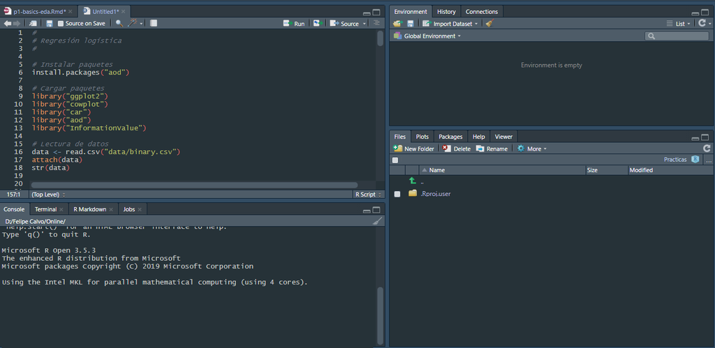

## Crear un proyecto

1. Abrir RStudio.
2. Clic en **File > New Project**
   - **New Directory > New Project** si queremos crear una nueva carpeta en nuestro equipo.
   - **Existing Directory** si queremos alojar nuestro proyecto en una carpeta ya creada.
3. Una vez creado el proyecto, podemos verificar que la ventana del programa se renombra y apunta a la carpeta donde está alojado.
4. Clic en **File > New File > R Script**. En la ventana que se carga ya podemos empezar a ejecutar nuestro código.

Al trabajar en un proyecto, una estructura útil para organizar los archivos es:

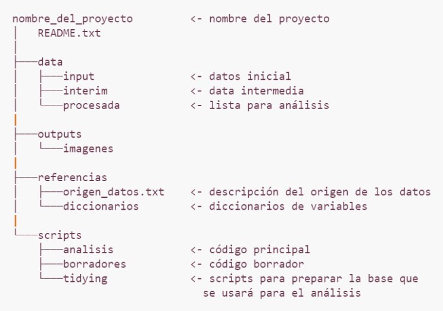

## Paquetes: instalar una vez, cargar muchas veces

- Cuando varias funciones son desarrolladas con un objetivos similar se suelen agrupar en *paquetes*, los cuales son colaborativamente distribuidos de forma gratuita.
- Para utilizar las funciones de un paquete es necesario instalar este paquete primero usando **install.packages()** y luego cargarlo en nuestro ambiente de trabajo usando **library()**.
- La instalación se realiza normalmente una sola vez; la carga se hace en cada sesión en la que se usará el paquete.
- [Lista de paquetes del CRAN](https://cran.r-project.org/web/packages/available_packages_by_date.html)
- [Lista de paquetes de Bioconductor](https://www.bioconductor.org/packages/release/bioc/)
- [rdrr.io](https://rdrr.io/)

```r
# Ejecutar una sola vez por computador
install.packages(c("tidyverse", "readxl", "haven", "rmarkdown"))
# Creo un listado con los paquetes que quiero verificar si están instalados
paquetes <- c("tidyverse", "readxl", "haven", "rmarkdown")
# Verifico que estén instalados
paquetes_disponibles <- paquetes[vapply(paquetes, requireNamespace,
                                         logical(1), quietly = TRUE)]
# Muestro los paquetes que están disponibles
paquetes_disponibles
```

Si un paquete no aparece en la lista, instálelo y vuelva a ejecutar el bloque. No es necesario instalar paquetes cada vez que se abre RStudio.

## Correr comandos/código

- Si se está trabajando en el panel **console** solamente es necesario presionar “Enter”.
- Si se está trabajando en un **script** es posible ejecutar los comandos presionando “Ctrl+Enter”, o haciendo clic en el botón *Run* en la parte derecha superior del panel de edición.

Antes de escribir código tenga presente qué pregunta quiere responder.

## Actualizar R y los paquetes (si ya lo tenía instalado)

Si ya tenías R instalado en Windows, puedes actualizar en bloque el programa y sus paquetes. Lo ideal es cerrar RStudio, abrir el programa R básico (RGui) que ya tienes instalado en tu computadora, y ejecutar esos códigos desde allí.

```r
# Instalar el paquete installr (solo Windows)
install.packages("installr")
# Cargar el paquete (solo Windows)
library(installr)
# Comando para actualizar R (solo Windows)
updateR()
# Comando para actualizar paquetes (Windows, macOS o Linux)
update.packages(checkBuilt = TRUE, ask = FALSE)
```

Si usas macOS o Linux, tienes que ir a la página oficial (CRAN), descargar el instalador .pkg de la nueva versión de R e instalarlo manualmente. Para actualizar los paquetes sí puedes usar la última línea del código de actualización *update.packages()*

## Buenas prácticas

- Usar **projects** (proyectos) para ajustar el ambiente de trabajo para un proyecto.
- Por reproducibilidad, facilidad y para tener los proyectos mejor organizados es mucho mejor usar **projects**.
- La idea es que cada proyecto tenga su propio espacio y esté *aislado*, de tal manera que los recursos y códigos de uno no interfieran con otros proyectos.
- Como en todo lenguaje de programación, a todo lo que le pongamos un nombre (variables, funciones, datos) hay que ponerle un *buen* nombre.
- ¡Siempre usa **scripts**! (si nunca antes has creado un *‘programa para un computador’* en este curso lo vas a hacer)
- Si aparecen errores, se puede copiar y pegar el error en Google, ChatGPT, Gemini o Claude.
- Comentar el código anteponiendo el símbolo “#” en la línea donde se desea insertar el comentario. Este proceso se puede hacer apoyándose de herramientas de programación asistida.
- A R podemos preguntarle cosas.
- Podemos instalar Github Copilot para RStudio para tener ayuda con la escritura de código.
- También podemos hacer depuración de código utilizando herramientas de inteligencia artificial tales como ChatGPT, Gemini, Claude, entre otras.

```r
?ayuda
?cualquier_cosa
?mean
??mean
```

## IA como asistente de programación

Las herramientas de IA pueden ayudar a explicar una función, proponer código o sugerir pruebas para un error. La secuencia recomendada es:

1. Formular primero la pregunta y describir los datos.
2. Pedir a la IA una explicación o una solución pequeña.
3. Ejecutar el código en R.
4. Revisar resultados, advertencias y supuestos.
5. Comparar con la documentación oficial.
6. Conservar únicamente una solución que pueda explicar.

No cargue en una herramienta de IA datos personales, credenciales, claves, información confidencial ni archivos cuya licencia no permita compartirlos. La IA puede inventar funciones, columnas o resultados; **ejecutar el código no sustituye comprenderlo**.

## Informes automáticos

R cuenta con un paquete llamado *knitr* con el cual podemos generar dinámicamente reportes, análisis y documentos. La técnica es la misma para darle formato a los cuadernos de Jupyter/notebooks de Google Colab que ven en el curso de Python.

- [Elegant, flexible, and fast dynamic report generation with R](https://yihui.org/knitr/)
- [RMarkdwon](https://rmarkdown.rstudio.com/)

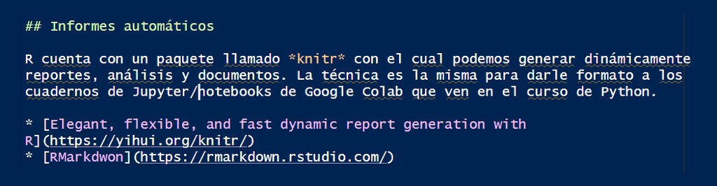

[figure not shown]

## Lista de verificación

- R y RStudio están instalados.
- El proyecto abre en la carpeta correcta.
- Los datos están dentro de `data/`.
- Las rutas del código son relativas.
- El análisis está guardado en un script (`.R`) o `.Rmd`.